# The Late Middle Ages/Early Modernity

25 October 2017

## Studying Question

If you're reading but not taking notes, you aren't reading

## Topics

- Black Death
- End of the ERE, emergence of Ottomans
  - Late-Byzantine art and thought
- Renaissance
  - Printing
  - Humanism
  - Vernacular literature

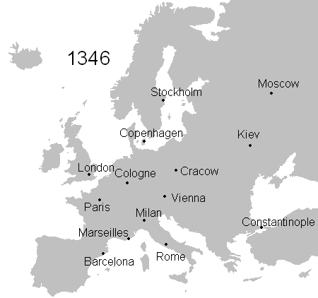

The spread of the Black Death across the Mediterranean and Europe, 1346-1353

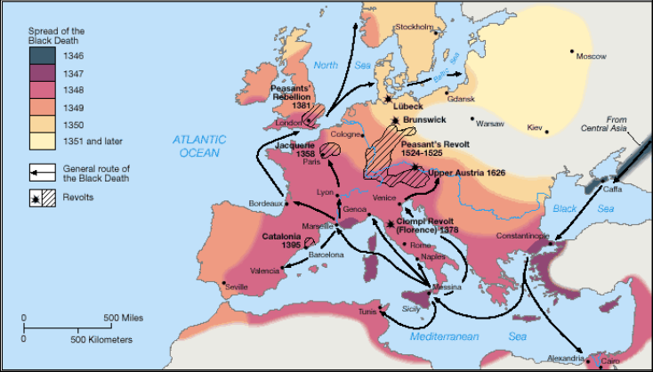

Extent of the Black Death and regions of significant peasant revolts

Not such were they as in the East, where an issue of blood from the nose was a manifest sign of inevitable death; but in men a women alike it first betrayed itself by the emergence of certain tumors in the groin or the armpits, some of which grew as large as a common apple, others as an egg, some more, some less. … Then the form of the malady began to change, black spots or livid making their appearance in many cases on the arm or the thigh or elsewhere, now few and large, then minute and numerous. And as the swellings had been and still were an infallible token of approaching death, such also were these spots on whomsoever they shewed themselves. … Oh, how many palaces, how many lovely houses, how many noble mansions once filled with families of lords and ladies remained empty even to the lowliest servant! Alas! How many memorable families, how many ample heritages, how many famous fortunes remained without a lawful heir!

From Giovanni Boccaccio, *The Decameron*, tr. D. Campbell (1921)

Boccaccio's complete text:

https://sourcebooks.fordham.edu/source/boccacio2.asp

See also on Jews blamed for the plague: https://sourcebooks.fordham.edu/halsall/jewish/1348-jewsblackdeath.asp

## What was it?

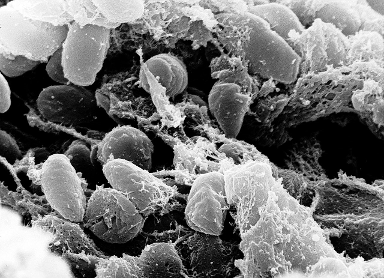

- *Yersinia pestis*, which also caused Justinian's Plague (541-750 AD) and the contemporary plague (C19-today)
- Identified through medical descriptions
- Confirmed through DNA analysis of medieval remains

## Consequences

- The Black Death was so bad, in part, because Europe has suffered a series of famines over the proceeding decades
  - The population of Europe would only again reach its level in 1300 by the early sixteenth century
- Social instability created endemic violence in many areas
  - 100 Years' War (1337-1453)
  - Brigandage
- "Feudal" structures teetered, then collapsed
  - Peasant revolts
  - Too little labour, too much land

## Contemporary account of the condition of France in the middle of the 100 Years' War

The affairs of the realm went from bad to worse, the public weal came to an end and brigands appeared on every side. The nobles hate and despise the rustics, they care no more for the good of the King or of their vassals; they oppress and despoil the peasants of their villages. They no longer trouble to defend the country: to tread their subjects under foot and to pillage them is their only care. From this day the land of France, hitherto glorious and honored throughout the world, became the laughing-stock of other nations.

From Evans, *Life in Medieval France* (1925), p. 188.

## New empires: Ottomans

- The ERE (Byzantium), under the **Palaiologan dynasty**, recovered Constantinople from Latin Crusaders in 1261
  - The Aegean remained divided numerous small Greek, Italian, Serbian, Bulgarian, and Turkish states
- **Ottomans**, one of the muslim Turkish sultanates, began expanding significantly in the 1350s (*recognize the date?*)
  - **Timurlane** (r.1370-1405) crushed them in 1402, but the Ottomans recovered from the 1420s
  - Constantinople fell, ending the ERE, in 1453, and became the Ottoman capital
  - Ottomans united Asia Minor the southern Balkans, the Legant, and Egypt by the ascension of **Suleiman the Magnificent** (1520-1566), and North Africa, Mesopotamia, and the northern Balkans (to the doorstep of Vienna) by his death.

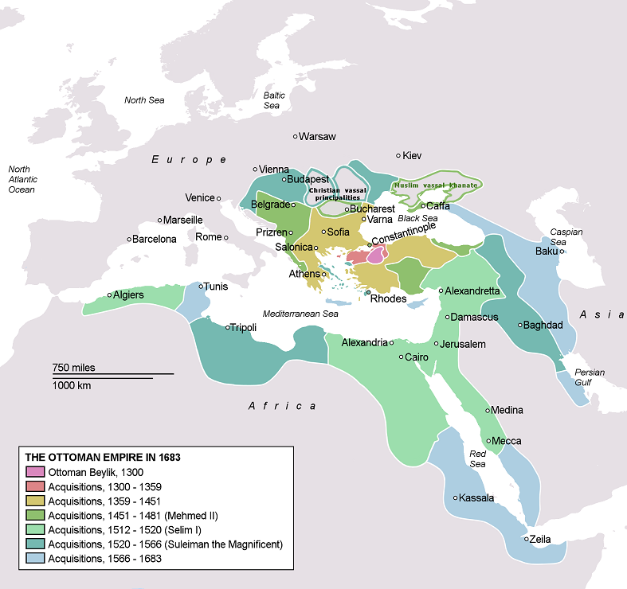

## Greek Origins of the Renaissance

- The sack of Constantinople by the 4th Crusade in 1204 triggered the first migration of Greek-speaking scholars westward
- **George Gemistus "Plethon"** (*c*.1355-1452) lectured in Florence in the 1420s (including to a young **Cosimo de'Medici**), reintroducing Plato to the West, and argued for returning to Ancient Greek Polytheism
- **George Argyropoulos** (*c*.1415-1487) was born and studied in Constantinople. After 1453, he moved to Italy, teaching in Padua, Florence and Rome and translated a number of Aristotle's works into Latin
- **Anna Notaras** (d. 1507), a member of the ERE's aristocracy, moved to Italy before its fall in 1453, and patronized the first Greek printing press in Venice in 1499

[figure not shown]

## The Printing Press

- The Black Death made more resources available at the cost of reduced labour pool
  - Paper (introduced to western Europe by Crusades) manufactured (https://www.youtube.com/watch?v=ZcMwkMcZ2v0)
  - **Woodblock printing** had existed, allowing for the rapid and precise reproduction of images
- **Johannes Gutenberg** (*c*.1400-1468) first developed **movable type**, printing the **Gutenberg Bibles** from 1450-1455.
  - Allowed for the rapid, accurate, and inexpensive mass-production of texts
  - The technology spread across Europe by the end of the century
  - Manuscripts still produced into the C16 and C17

[figure not shown]

A copy of the **Gutenberg Bible** held in the Pelplin Diocesan Museum in Pelplin, Poland

## Vernacular Literature

- In Western Europe, Latin had long dominated as the language of government, education, religion
  - In the eastern Mediterranean, preexisting literary traditions in Greek, Arabic, Slavonic, Armenian, Syriac, etc.
- **Dante Alighieri** (*c*.1265-1321) wrote the *Divine Comedy* in the Italian vernacular
- **Geoffrey Chaucer** (*c*.1343-1400), now known principally for the *Canterbury Tales* which legitimated the English vernacular
  - During the 100 Years' War, the **Plantagenet** court culture finally changed from French to English
- **Christine de Pisan** (1364-*c*.1430) was an Italian-born French author who wrote in Middle French
  - **Quarelle des Femmes**

An extraordinary thought became planted in my mind which made me wonder why on earth it was that so many men, both clerks and others, have said and continue to say and write such awful, damning things about women and their ways. I was at a loss as to how to explain it. It is not just a handful of writers who do this. It Is all manner of philosophers, poets and orators too numerous to mention, who all seem to speak with one voice and are unanimous in their view that female nature is wholly given up to vice. … In order to judge in all fairness and without prejudice whether what so many famous men have said about us is true, I thought about other women I know, the many princesses and countless ladies of all different social ranks who have shared their private and personal thoughts with me. No matter which way I look at it and no matter how much I turned the question over in my mind, I could find no evidence from my own experience to bear out such a negative view of female nature and habits.

Christine de Pisan, *The Book of the City of Ladies*, tr. R. Brown-Grant, pp. 5-6

## Humanism

- While **Scholastics** had eagerly studied the natural philosophy of the ancient world, **humanists** turned their focus to classical literature, history, and culture
  - Humanists wrote in both Latin and the vernacular
- **Petrarch** (1304-1374) the founder of humanism, a poet and philosopher who pioneered a new synthesis of a "secular"" interpretation of antiquity with Christian faith
- **Basilios Bessarion** (1403-1472), a Greek Catholic cardinal who studied under Plethon. He produced translations as well as his own philosophical and theological works
- **Niccolo Machiavelli** (1469-1527), a politician, historian, philosopher and humanist, now best known for his political essay *The Prince*

## **The** Renaissance

- Literally, "rebirth"
  - Began in Florence in the mid-C14 and lasted until the C17
  - A revolution in learning, the physical arts, music, natural philosophy (the "sciences", though be cautious about that concept), and religion

Important artists

- **Jan van Eyck** (*c*.1390-1441) a Dutch painter and the principal figure of the early Northern Renaissance
- **Leonardo da Vinci** (1452-1519), possibly the most talented person to ever live, a *polymath* whose interests included just about everything, and the archetype of the "Universal Genius" or the "Renaissance Man"
  - The "other *TMNT*": **Donatello** (1386-1466), **Raphael** (1483-1520), **Michaelangelo** (1475-1564)

[figure not shown]

**Albrecht Dürer** (1471-1528), *Landscape with Canon* (1518), etching on iron plates

A group of Turks standing next to an antiquated cannon, reflecting contemporary concerns with Ottoman expansion

## Representations in Popular Culture

Theatre and Film

- Shakespeare's historical plays (*Richard II*, *Henry IV Parts I & II*, *Henry V*, *Henry VI Parts I, II, and III*, *Richard III*)
- *The Messenger: The story of Joan of Arc* (1999) [see previous cautions about the historicity of *Braveheart*]

Games

- *Assassins' Creed II*, *Brotherhood*, and *Revelations*
- *Europa Universalis IV*

## Further Reading

Primary

- Fordham's Internet Medieval Sourcebook: Renaissance (https://sourcebooks.fordham.edu/Halsall/sbook1x.asp)

Secondary

- J. Huizinga, *The Autumn of the Middle Ages* (1921) (tr. Payton and Mammitzsch, 1996)
- D.M. Nicol, *The Last Centuies of Byzantium, 1261-1453* (1993)
- D. Seward, *The Hundred Years War. The English in France 1337-1453* (1978)